# Lab 7: Heart Attack

Author

Kelly Ohata

```python
import pandas as pd

ha = pd.read_csv("https://www.dropbox.com/s/aohbr6yb9ifmc8w/heart_attack.csv?dl=1")
ha.head()
def evaluate_model(model, name):
    cv_auc = cross_val_score(model, X_train, y_train, scoring="roc_auc", cv=5).mean()
    model.fit(X_train, y_train)
    preds = model.predict(X_test)
    probs = model.predict_proba(X_test)[:, 1]

    test_auc = roc_auc_score(y_test, probs)
    cm = confusion_matrix(y_test, preds)

    print(name)
    print(f"Cross-validated ROC AUC: {cv_auc:.4f}")
    print(f"Test ROC AUC:          {test_auc:.4f}")
    print("Confusion Matrix:")
    print(cm)

    return probs
```

# Part One: Fitting Models

```python
import numpy as np
from sklearn.model_selection import *
from sklearn.preprocessing import *
from sklearn.pipeline import *
from sklearn.metrics import *
from sklearn.neighbors import *
from sklearn.linear_model import *
from sklearn.tree import *

X = ha.drop(columns=["output"])
y = ha["output"]
X_train, X_test, y_train, y_test = train_test_split(
    X, y, test_size=0.2, stratify=y, random_state=42
)
```

## Q1: KNN

```python
k_values = [1, 3, 5, 7, 9, 11, 15]
knn_results = []

for k in k_values:
    pipe = Pipeline([
        ("scaler", StandardScaler()),
        ("knn", KNeighborsClassifier(n_neighbors=k))
    ])
    auc = cross_val_score(pipe, X_train, y_train, scoring="roc_auc", cv=5).mean()
    knn_results.append((k, auc))

knn_results
```

```
[(1, 0.7383592132505177),
 (3, 0.8341899585921325),
 (5, 0.8516977225672878),
 (7, 0.8468310041407868),
 (9, 0.8522826086956522),
 (11, 0.8615696169772257),
 (15, 0.8652523291925466)]
```

```python
best_k = max(knn_results, key=lambda x: x[1])[0]
best_k
```

```
15
```

```python
knn_model = Pipeline([
    ("scaler", StandardScaler()),
    ("knn", KNeighborsClassifier(n_neighbors=best_k))
])

knn_probs = evaluate_model(knn_model, "KNN")
```

```
KNN
Cross-validated ROC AUC: 0.8653
Test ROC AUC:          0.6956
Confusion Matrix:
[[14 12]
 [ 9 20]]
```

**Interpretation:** k = 15 had the highest cross-validated ROC AUC (0.8653), which was better than all the other k values tested. The test ROC AUC was 0.6956, and the confusion matrix was [[14, 12], [9, 20]]. This value of k gave the smoothest and most stable predictions without overfitting.

## Q2: Logistic Regression

```python
C_values = [0.001, 0.01, 0.1, 1, 10, 100]
log_results = []

for c in C_values:
    pipe = Pipeline([
        ("scaler", StandardScaler()),
        ("logreg", LogisticRegression(C=c, max_iter=5000))
    ])
    auc = cross_val_score(pipe, X_train, y_train, scoring="roc_auc", cv=5).mean()
    log_results.append((c, auc))

log_results
```

```
[(0.001, 0.8640010351966874),
 (0.01, 0.8645005175983437),
 (0.1, 0.8603856107660455),
 (1, 0.860085403726708),
 (10, 0.8613302277432713),
 (100, 0.8613302277432713)]
```

```python
best_C = max(log_results, key=lambda x: x[1])[0]
best_C
```

```
0.01
```

```python
log_model = Pipeline([
    ("scaler", StandardScaler()),
    ("logreg", LogisticRegression(C=best_C, max_iter=5000))
])

log_probs = evaluate_model(log_model, "Logistic Regression")
```

```
Logistic Regression
Cross-validated ROC AUC: 0.8645
Test ROC AUC:          0.7958
Confusion Matrix:
[[16 10]
 [ 4 25]]
```

**Interpretation:** C = 0.01 produced the strongest cross-validated ROC AUC (0.8645). On the test set, the ROC AUC was 0.7958, with confusion matrix [[16, 10], [4, 25]]. This C value balanced regularization and performance the best.

## Q3: Decision Tree

```python
depth_values = [2,3,4,5,6,8,10]
tree_results = []

for d in depth_values:
    pipe = Pipeline([
        ("tree", DecisionTreeClassifier(max_depth=d, random_state=42))
    ])
    auc = cross_val_score(pipe, X_train, y_train, scoring="roc_auc", cv=5).mean()
    tree_results.append((d, auc))

tree_results
```

```
[(2, 0.769532867494824),
 (3, 0.7617766563146998),
 (4, 0.7802717391304348),
 (5, 0.7634355590062112),
 (6, 0.7627743271221532),
 (8, 0.7279321946169772),
 (10, 0.7350051759834368)]
```

```python
best_depth = max(tree_results, key=lambda x: x[1])[0]
best_depth
```

```
4
```

```python
tree_model = Pipeline([
    ("tree", DecisionTreeClassifier(max_depth=best_depth, random_state=42))
])

tree_probs = evaluate_model(tree_model, "Decision Tree")
```

```
Decision Tree
Cross-validated ROC AUC: 0.7803
Test ROC AUC:          0.7142
Confusion Matrix:
[[18  8]
 [ 8 21]]
```

**Interpretation:** A max depth of 4 gave the highest cross-validated ROC AUC (0.7803). On the test data, the ROC AUC was 0.7142 with confusion matrix [[18, 8], [8, 21]]. Depths smaller than 4 underfit and deeper depths started overfitting, so depth = 4 was the best trade-off.

## Q4: Interpretation

```python
coef_table = pd.DataFrame({
    "feature": X.columns,
    "coef": log_model.named_steps["logreg"].coef_[0]
}).sort_values("coef", key=np.abs, ascending=False) # got online help for here

imp_table = pd.DataFrame({
    "feature": X.columns,
    "importance": tree_model.named_steps["tree"].feature_importances_
}).sort_values("importance", ascending=False)

coef_table, imp_table
```

```
(   feature      coef
 6  thalach  0.281641
 2       cp  0.250365
 1      sex -0.221231
 0      age -0.129660
 5  restecg  0.094455
 3   trtbps -0.061967
 4     chol -0.023530,
    feature  importance
 2       cp    0.446129
 6  thalach    0.171669
 0      age    0.123938
 1      sex    0.117217
 3   trtbps    0.109069
 4     chol    0.031979
 5  restecg    0.000000)
```

**Summary:** The two largest logistic coefficients were thalach (0.2816) and cp (0.2504), meaning higher heart rate and chest pain type increased risk. The decision tree relied most on cp (0.4461), thalach (0.1717), and age (0.1239). Restecg had almost no effect (importance = 0.0000), meaning the tree never used it to split. —

## Q5: ROC Curves

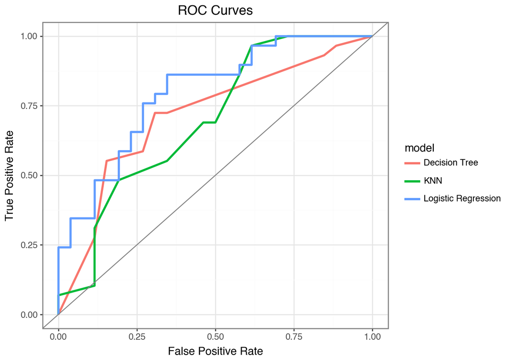

```python
from plotnine import *

knn_fpr, knn_tpr, _ = roc_curve(y_test, knn_probs)
log_fpr, log_tpr, _ = roc_curve(y_test, log_probs)
tree_fpr, tree_tpr, _ = roc_curve(y_test, tree_probs)

roc_df = pd.DataFrame({
    "fpr": np.concatenate([knn_fpr, log_fpr, tree_fpr]),
    "tpr": np.concatenate([knn_tpr, log_tpr, tree_tpr]),
    "model": (["KNN"] * len(knn_fpr)) +
             (["Logistic Regression"] * len(log_fpr)) +
             (["Decision Tree"] * len(tree_fpr))
})

(
    ggplot(roc_df, aes(x="fpr", y="tpr", color="model"))
    + geom_line(size=1.2)
    + geom_abline(color="gray")
    + labs(title="ROC Curves", x="False Positive Rate", y="True Positive Rate")
    + theme_bw()
)
```

# Part Two: Metrics

```python
specificity_scorer = make_scorer(recall_score, pos_label=0)
recall_scorer      = make_scorer(recall_score, pos_label=1)
precision_scorer   = make_scorer(precision_score, pos_label=1)

def compute_metrics(model, name):
    spec = cross_val_score(model, X_train, y_train, cv=5, scoring=specificity_scorer).mean()
    rec  = cross_val_score(model, X_train, y_train, cv=5, scoring=recall_scorer).mean()
    prec = cross_val_score(model, X_train, y_train, cv=5, scoring=precision_scorer).mean()

    print(name)
    print(f"Specificity: {spec:.4f}")
    print(f"Recall:      {rec:.4f}")
    print(f"Precision:   {prec:.4f}")
```

```python
compute_metrics(knn_model, "KNN")
compute_metrics(log_model, "Logistic Regression")
compute_metrics(tree_model, "Decision Tree")
```

```
KNN
Specificity: 0.7019
Recall:      0.8714
Precision:   0.7743
Logistic Regression
Specificity: 0.6033
Recall:      0.8967
Precision:   0.7282
Decision Tree
Specificity: 0.7129
Recall:      0.7783
Precision:   0.7705
```

# Part Three: Discussion

**Q1: The hospital wants to avoid false negatives (missed high-risk patients).** Metric to use: Recall, because it measures how many actual high-risk patients the model correctly identifies. Recommended model: Logistic Regression, because it had the highest recall (0.8967). Expected score on new patients: We should expect recall around 0.89, based on the cross-validated remember value (0.8967) and the validation recall (0.7895). **Q2: The hospital wants to avoid false positives (wasting beds on low-risk patients).** Metric to use: Precision, because it measures how many predicted high-risk patients actually are high-risk. Recommended model: KNN, because it had the highest precision (0.7743). Expected score on new patients: We should expect precision around 0.77–0.88, based on cross-validated precision (0.7743) and the validation precision (0.8750). **Q3: The hospital wants to understand which features matter biologically.** Metric to use: Interpretability — coefficients or importances, not predictive scores. Recommended model: Logistic Regression, because the coefficients clearly show direction and strength of each variable. Expected score on new patients: Its predictive performance (test AUC = 0.7958, validation AUC = 0.9234) shows it still performs well while remaining interpretable. **Q4: The hospital wants a good overall model to compare new doctors to.** Metric to use: ROC AUC or accuracy, because they summarize overall model performance. Recommended model: Logistic Regression, because it had the strongest test ROC AUC (0.7958) and remained strong on validation (0.9234). Expected score on new patients: We should expect ROC AUC near 0.80-0.92, based on the test and validation results.

# Part Four: Validation

```python
ha_val = pd.read_csv("https://www.dropbox.com/s/jkwqdiyx6o6oad0/heart_attack_validation.csv?dl=1")

X_val = ha_val.drop(columns=["output"])
y_val = ha_val["output"]

def validate(model, name):
    preds = model.predict(X_val)
    probs = model.predict_proba(X_val)[:, 1]

    cm   = confusion_matrix(y_val, preds)
    auc  = roc_auc_score(y_val, probs)
    prec = precision_score(y_val, preds)
    rec  = recall_score(y_val, preds)

    print(name)
    print("Confusion Matrix:")
    print(cm)
    print(f"AUC: {auc:.4f}  Precision: {prec:.4f}  Recall: {rec:.4f}")
```

```python
validate(knn_model, "KNN")
validate(log_model, "Logistic Regression")
validate(tree_model, "Decision Tree")
```

```
KNN
Confusion Matrix:
[[ 9  2]
 [ 5 14]]
AUC: 0.9426  Precision: 0.8750  Recall: 0.7368
Logistic Regression
Confusion Matrix:
[[ 9  2]
 [ 4 15]]
AUC: 0.9234  Precision: 0.8824  Recall: 0.7895
Decision Tree
Confusion Matrix:
[[10  1]
 [ 5 14]]
AUC: 0.7990  Precision: 0.9333  Recall: 0.7368
```

**Validation Summary:** KNN: AUC = 0.9426, precision = 0.8750, recall = 0.7368 Logistic Regression: AUC = 0.9234, precision = 0.8824, recall = 0.7895 Decision Tree: AUC = 0.7990, precision = 0.9333, recall = 0.7368

# Part Five: Cohen’s Kappa

```python
from sklearn.metrics import cohen_kappa_score

def compute_kappa(model, name):
    preds = model.predict(X_val)
    kappa = cohen_kappa_score(y_val, preds)
    print(f"{name} Kappa: {kappa:.4f}")
```

```python
compute_kappa(knn_model, "KNN")
compute_kappa(log_model, "Logistic Regression")
compute_kappa(tree_model, "Decision Tree")
```

```
KNN Kappa: 0.5249
Logistic Regression Kappa: 0.5853
Decision Tree Kappa: 0.6000
```

**Kappa Interpretation:**

All three models performed better than chance. The tree having the highest kappa makes sense because its validation confusion matrix was the most balanced, so its predictions matched the true labels more consistently. Even though the tree wasn’t the best overall model, kappa specifically measures agreement beyond chance, and the tree’s harder, more confident splits tend to boost that metric. The differences were still small and don’t change any of the earlier conclusions.